# WIM Workshop

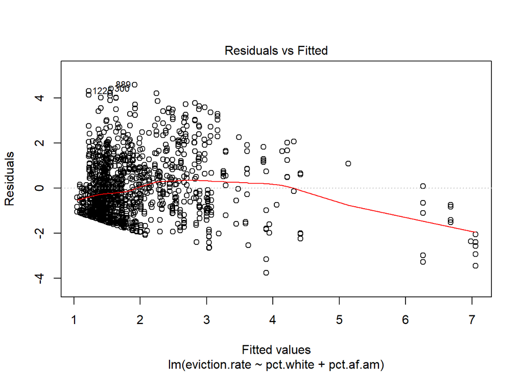

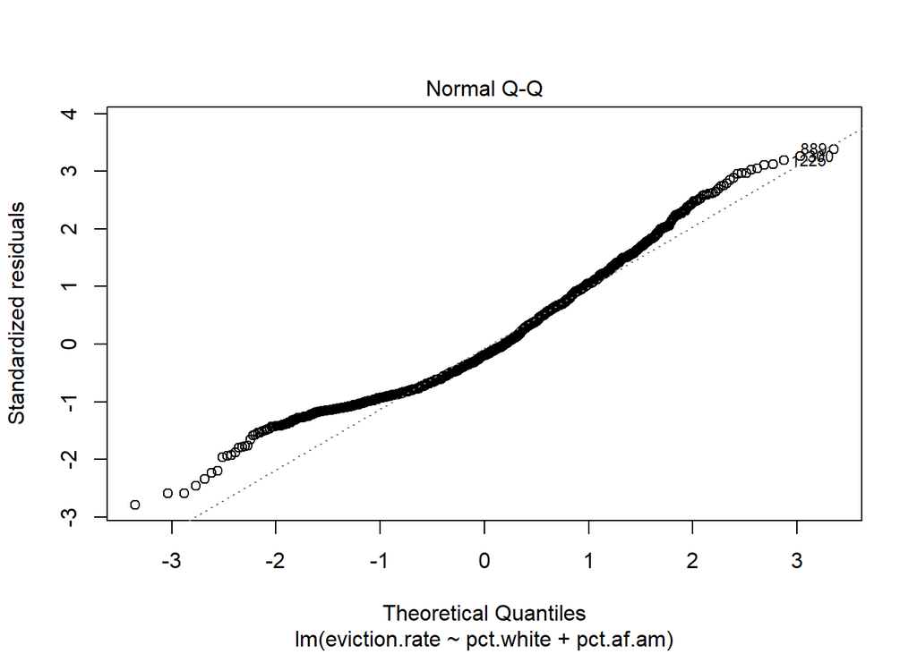

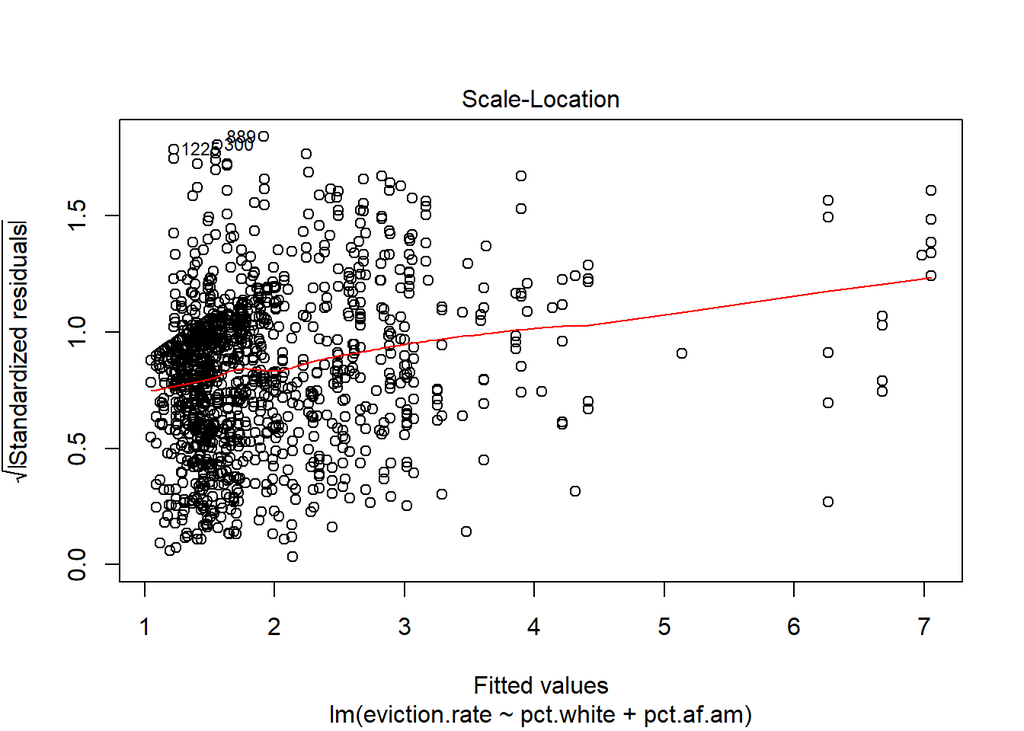

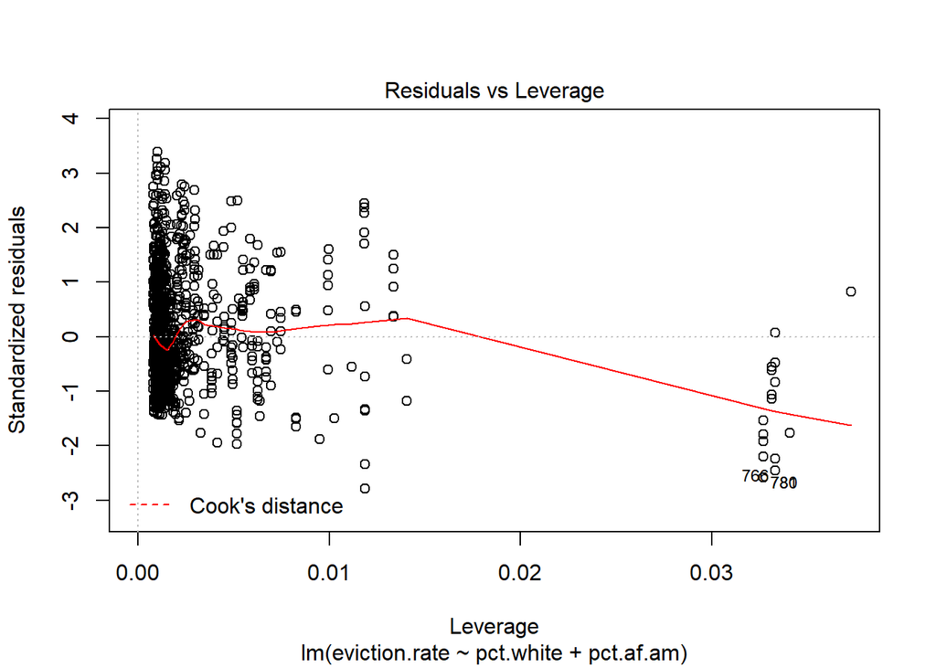

```r
plot(model2)
```

…slightly.

Let’s add poverty rate as another variable, and let’s add interaction terms too:

```r
#remember we removed outliers in df2
model3 <- lm(eviction.rate ~ pct.white*poverty.rate + pct.af.am*poverty.rate + poverty.rate, data=df2)
summary(model3)
```

```
##
## Call:
## lm(formula = eviction.rate ~ pct.white * poverty.rate + pct.af.am *
##     poverty.rate + poverty.rate, data = df2)
##
## Residuals:
##     Min      1Q  Median      3Q     Max
## -3.8312 -1.0284 -0.2199  0.8403  4.4761
##
## Coefficients:
##                         Estimate Std. Error t value Pr(>|t|)
## (Intercept)            18.403559   4.895029   3.760 0.000178 ***
## pct.white              -0.176964   0.050540  -3.501 0.000479 ***
## poverty.rate           -0.352848   0.492242  -0.717 0.473621
## pct.af.am               0.327932   0.108750   3.015 0.002618 **
## pct.white:poverty.rate  0.003690   0.005073   0.727 0.467204
## poverty.rate:pct.af.am -0.025892   0.010275  -2.520 0.011861 *
## ---
## Signif. codes:  0 '***' 0.001 '**' 0.01 '*' 0.05 '.' 0.1 ' ' 1
##
## Residual standard error: 1.331 on 1243 degrees of freedom
## Multiple R-squared:  0.3082, Adjusted R-squared:  0.3054
## F-statistic: 110.7 on 5 and 1243 DF,  p-value: < 2.2e-16
```

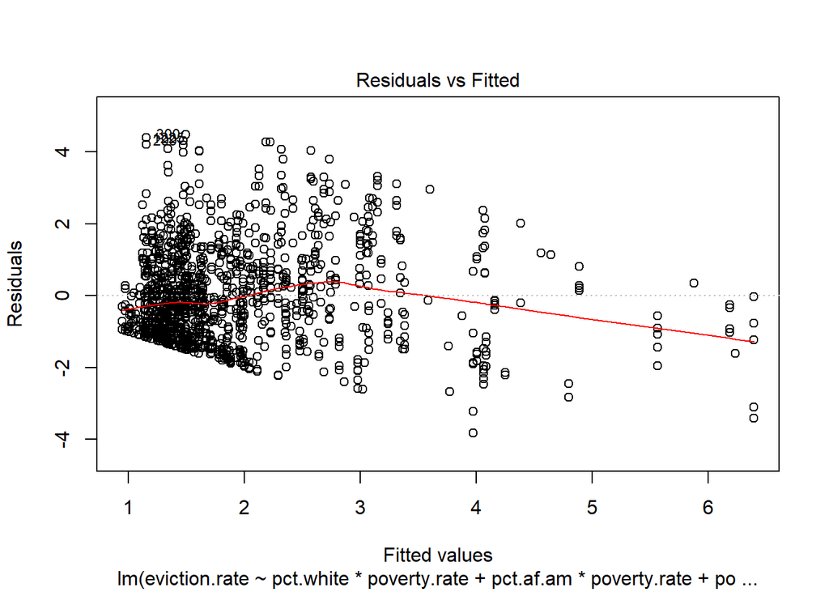

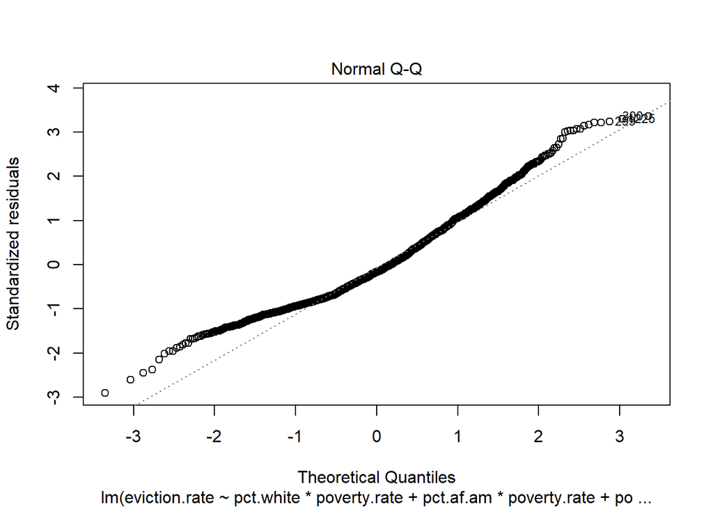

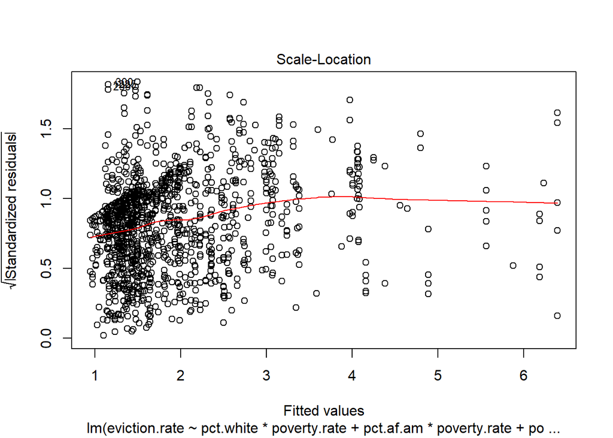

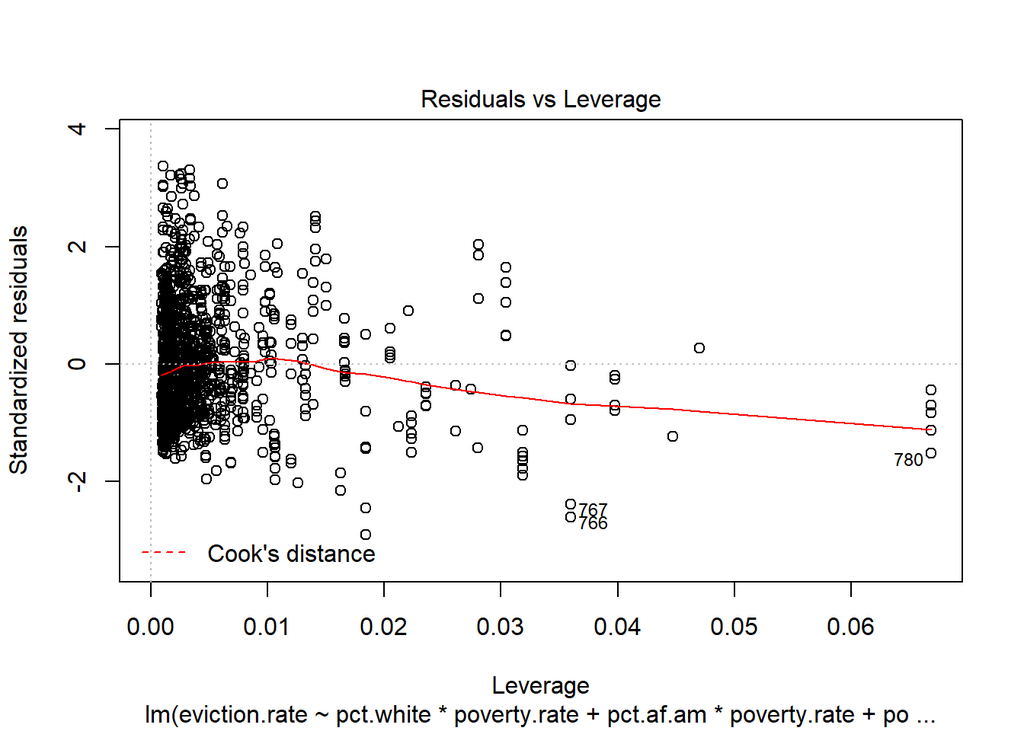

```r
plot(model3)
```

let’s compare nested models 2 and 3:

```r
anova(model2,model3)
```

```
## Analysis of Variance Table
##
## Model 1: eviction.rate ~ pct.white + pct.af.am
## Model 2: eviction.rate ~ pct.white * poverty.rate + pct.af.am * poverty.rate +
##     poverty.rate
##   Res.Df    RSS Df Sum of Sq      F    Pr(>F)
## 1   1246 2284.9
## 2   1243 2200.7  3    84.251 15.863 3.991e-10 ***
## ---
## Signif. codes:  0 '***' 0.001 '**' 0.01 '*' 0.05 '.' 0.1 ' ' 1
```

we can also check the AIC and BIC outputs:

```r
AIC(model3)
```

```
## [1] 4265.954
```

```r
BIC(model3)
```

```
## [1] 4301.865
```

## Robust standard errors

To deal with heteroskedasticity, you can ask R to estimate heteroskedasticity consistant (HC) variance covariance matrix before showing the summary output. for coeftest() function you will need lmtest package, and for vcovHC() you will need the sandwich package

```r
library(sandwich)
library(lmtest)
coeftest(model3, vcov = vcovHC(model3))
```

```
##
## t test of coefficients:
##
##                          Estimate Std. Error t value Pr(>|t|)
## (Intercept)            18.4035588  5.1815722  3.5517 0.000397 ***
## pct.white              -0.1769639  0.0532027 -3.3262 0.000906 ***
## poverty.rate           -0.3528476  0.5578332 -0.6325 0.527155
## pct.af.am               0.3279321  0.1173144  2.7953 0.005264 **
## pct.white:poverty.rate  0.0036896  0.0057170  0.6454 0.518804
## poverty.rate:pct.af.am -0.0258918  0.0115799 -2.2359 0.025534 *
## ---
## Signif. codes:  0 '***' 0.001 '**' 0.01 '*' 0.05 '.' 0.1 ' ' 1
```

It’s is also easy to change the estimation method for the variance-covariance matrix:

```r
coeftest(model3, vcov = vcovHC(model3, type = "HC0"))
```

```
##
## t test of coefficients:
##
##                          Estimate Std. Error t value  Pr(>|t|)
## (Intercept)            18.4035588  5.0765222  3.6252 0.0003004 ***
## pct.white              -0.1769639  0.0521234 -3.3951 0.0007077 ***
## poverty.rate           -0.3528476  0.5461989 -0.6460 0.5183949
## pct.af.am               0.3279321  0.1153541  2.8428 0.0045446 **
## pct.white:poverty.rate  0.0036896  0.0055977  0.6591 0.5099348
## poverty.rate:pct.af.am -0.0258918  0.0113667 -2.2779 0.0229045 *
## ---
## Signif. codes:  0 '***' 0.001 '**' 0.01 '*' 0.05 '.' 0.1 ' ' 1
```

## Create a coefficient plot

```r
install.packages('dotwhisker',repos = "http://cran.us.r-project.org")
library(dotwhisker)
```

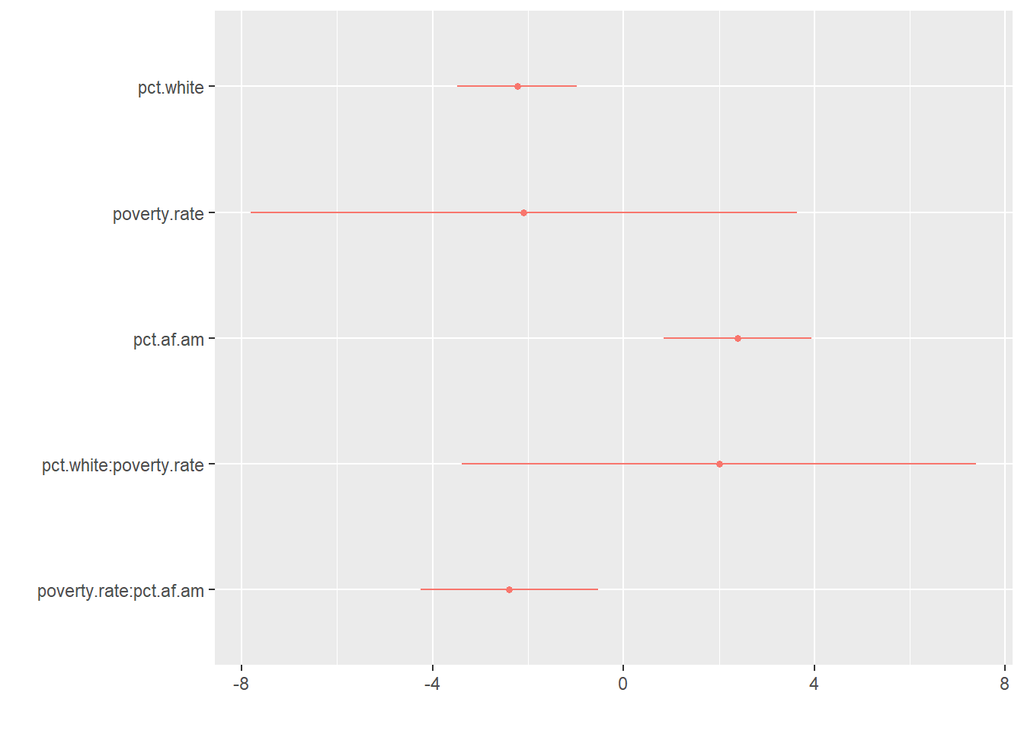

```r
# draw a dot-and-whisker plot
dwplot(model3) #default, 95% CI
```

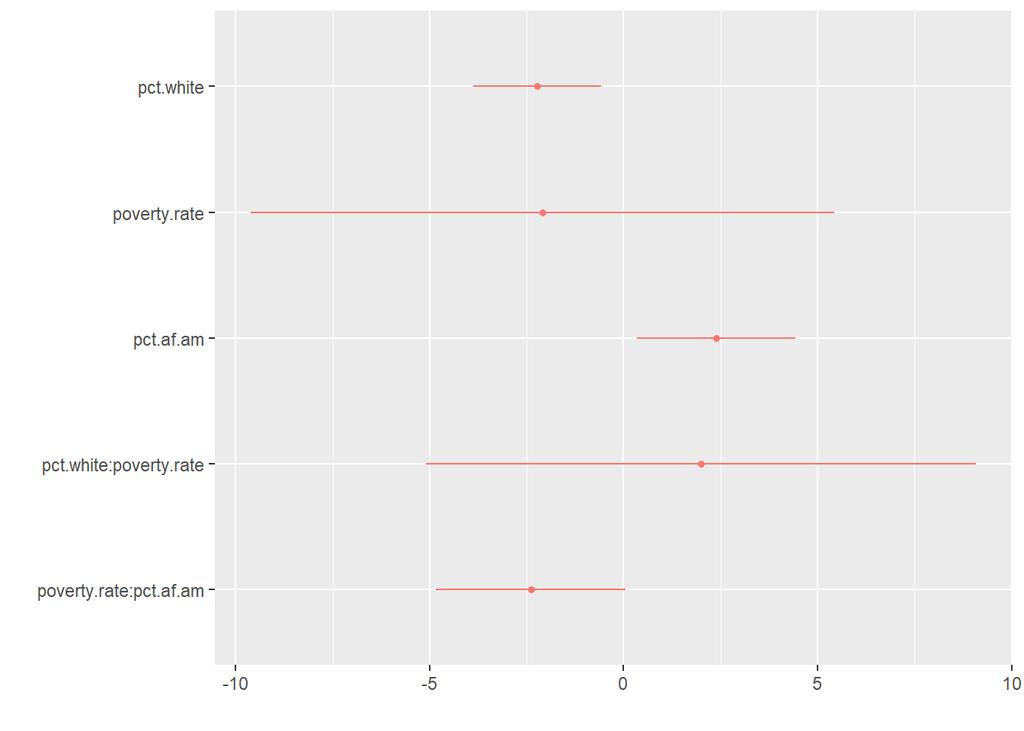

```r
dwplot(model3, conf.level = .99)
```

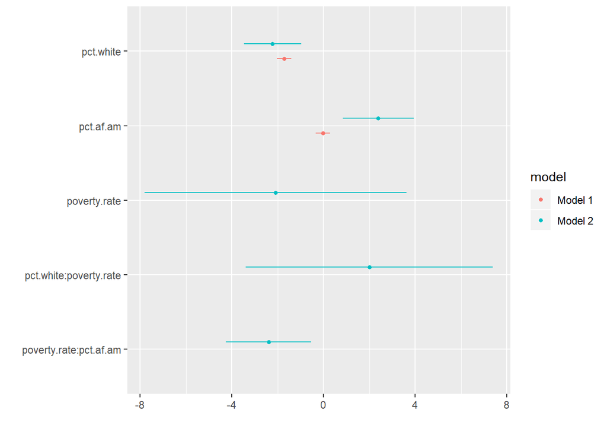

```r
dwplot(list(model2, model3)) #intercept is excluded by default
```

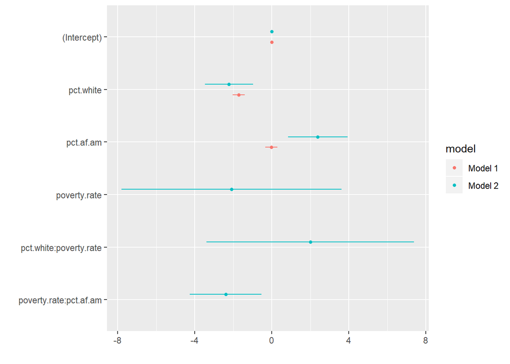

```r
dwplot(list(model2, model3), show_intercept = TRUE) #intercept is excluded by default
```

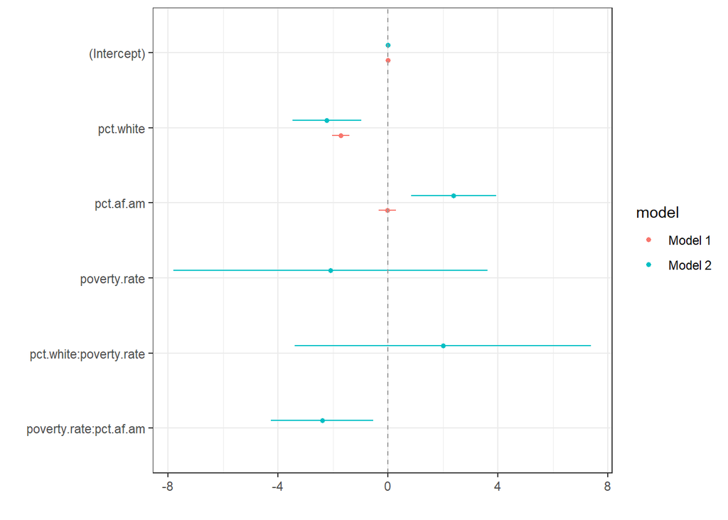

```r
dwplot(list(model2, model3), show_intercept = TRUE)+
  theme_bw() +
  geom_vline(xintercept = 0, colour = "grey60", linetype = 2) #bcs this is ggplot you can add parameters as in the way you would add things to any ggplot...
```